# Métodos Clássicos para Previsão de Séries Temporais

Filipe Coelho de Lima Duarte

### Atividade:

Cada aluno deverá escrever um relatório contendo as análises e incluindo seguinte:

1. Utilizar, no experimento, 2 a 4 séries temporais, por exemplo, do repositório TDSL. Devem ser escolhidas séries temporais com caraterísticas diferentes, sendo uma delas financeira ou climática (para apresentar volatilidade).
2. Para cada série, fazer previsões usando os modelos Holt-Winters, AR, ARMA, ARIMA, GARCH e Kalman. Apresentar os gráficos de treinamento, teste e o resultado da previsão considerando o erro médio quadrático (MSE).
3. Para cada modelo gerado, JUSTIFICAR a escolha dos parâmetros usados. Para isso utilizar os gráficos de Autocorrelação e Autocorrelação Parcial.

### Bibliotecas utilizadas

Este trabalho tem como objetivo apresentar um estudo dos métodos clássicos para previsão de séries temporais da disciplina de Tópicos Especiais em Inteligência Artificial IV: Séries Temporais. Apresentamos abaixo as bibliotecas utilizadas e a função de cálculo do erro quadrático médio (MSE).

```r
library(forecast)
library(readr)
library(ggplot2)
library(tseries)
library(quantmod)
library(sspir)
MSE <- function(y, yhat){
  mse <- mean((y - yhat)^2)
  return(mse)
}
```

### 1ª Série Temporal: Letras do Tesouro Nacional com vencimento em 01-01-2021

Os dados foram coletados por meio do pacote ‘GetTDData’.

Abaixo, apresento o gráfico da série temporal completa para o período de 01/01/2015 - 20/09/2019, as 10 primeiras observações e um resumo estatístico:

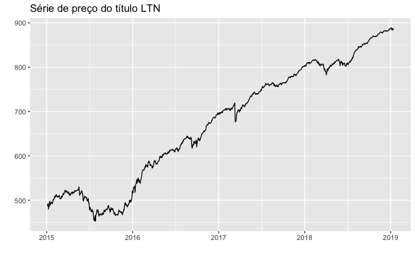

```
Os 10 primeiros valores da série:
 [1] 487.04 490.78 492.53 480.37 485.28 485.27 493.99 498.03 488.47 491.45

Estatísticas:
   Min. 1st Qu.  Median    Mean 3rd Qu.    Max.
  452.3   528.0   695.2   672.9   799.0   889.2

desvio-padrão = 133.1909
```

O primeiro passo da modelagem será realizar a decomposição da série para verificar se há comportamento de tendência e sazonalidade:

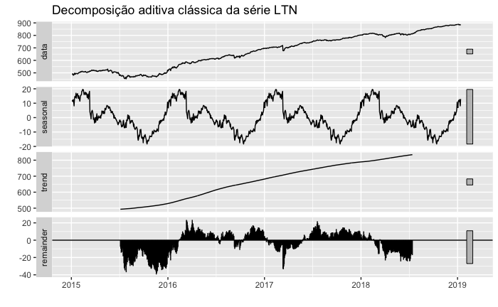

O gráfico da decomposição demonstra uma a existência de uma tendência crescente linear e um comportamento sazonal. Desse modo, selecionaremos uma parcela dos dados para realizar o procedimento de treinamento (estimação dos parâmetros) que compreenderá o período: 10/03/2015 - 31/12/2017. Os dados de teste representam a amostra que servirá de base para avaliar a qualidade de previsão dos modelos. O período de teste será entre: 01/01/2018 e 20/09/2019.

```
Tamanho da amostra de treinamento : 751
Tamanho da amostra de teste : 256
```

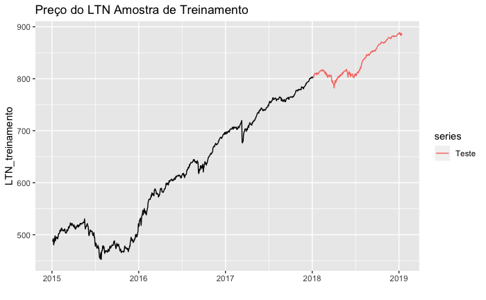

Percebe-se por meio do gráfico de treinamento e teste que a série de preços da LTN possui um comportamento padrão a partir do ano de 2016. A seguir realizaremos a modelagem dos dados.

#### Holt-Winters

O modelo Holt-Winters utiliza-se de três equações para modelar a série temporal, são elas: sazonalidade, tendência e nível. O modelo aditivo utilizado possui a seguinte equação:
$$Z_t = \mu_t + T_t + S_t + a_t$$

```
MSE Holt Winters = 1181.704
```

#### AR

Diz-se que uma série temporal $x_t$ é um processo autorregressivo de ordem $p$, abreviado como $AR(p)$, se

$$x_t = \alpha _1 x_{t-1} + \alpha _2 x_{t-2} + ... + \alpha _p x_{t-p} + w_t$$
em que, $w_t$ é um ruído branco e $\alpha _i$ são os parâmetros do modelo de tal maneira que são diferentes de zero. Além disso, o modelo AR tem como premissa a estacionariedade da série temporal. Sendo assim, se a série temporal não for estacionária, será necessário diferenciá-la.

Utilizaremos o teste Augmented Dickey-Fuller (ADF) para avaliar se a série possui raiz unitária, isto é, se ela não é estacionária. A hipótese nula do teste diz que existe pelo menos uma raiz unitária dentro do círculo unitário, ou seja, que a série é não estacionária.

```r
adf.test(LTN_treinamento)
```

```
    Augmented Dickey-Fuller Test

data:  LTN_treinamento
Dickey-Fuller = -1.84, Lag order = 9, p-value = 0.646
alternative hypothesis: stationary
```

```r
adf.test(LTN_teste)
```

```
    Augmented Dickey-Fuller Test

data:  LTN_teste
Dickey-Fuller = -2.0133, Lag order = 6, p-value = 0.5702
alternative hypothesis: stationary
```

Como se pode verificar, o p-value foi 0.646 que é maior do que 5%. Esse resultado nos diz que não temos evidências suficientes para rejeitar a hipótese nula de que a série é não estacionária. Portanto, precisamos realizar a primeira diferença de tal maneira a transformar a série de preços da LTN em uma série estacionária.

```r
LTN_treinamento_diff <- diff(LTN_treinamento)
LTN_teste_diff <- diff(LTN_teste)
```

Realizada a primeira diferença para a série de preços da LTN, realizaremos novamente o teste ADF.

```r
adf.test(LTN_treinamento_diff)
```

```
p-value smaller than printed p-value
```

```
    Augmented Dickey-Fuller Test

data:  LTN_treinamento_diff
Dickey-Fuller = -9.0091, Lag order = 9, p-value = 0.01
alternative hypothesis: stationary
```

```r
adf.test(LTN_teste_diff)
```

```
p-value smaller than printed p-value
```

```
    Augmented Dickey-Fuller Test

data:  LTN_teste_diff
Dickey-Fuller = -4.4298, Lag order = 6, p-value = 0.01
alternative hypothesis: stationary
```

Os resultados apresentam p-valor menores do que 5%, indicando que há evidências para rejeitar a hipótese nula de presença de raiz unitária. Agora podemos utilizar o modelo AR para as séries diferenciadas.

O primeiro passo na identificação de um modelo autorregressivo se dá por meio da análise do correlograma acf e do pacf.

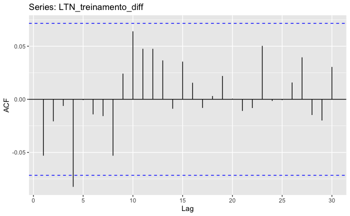

```r
ggAcf(LTN_treinamento_diff,30)
```

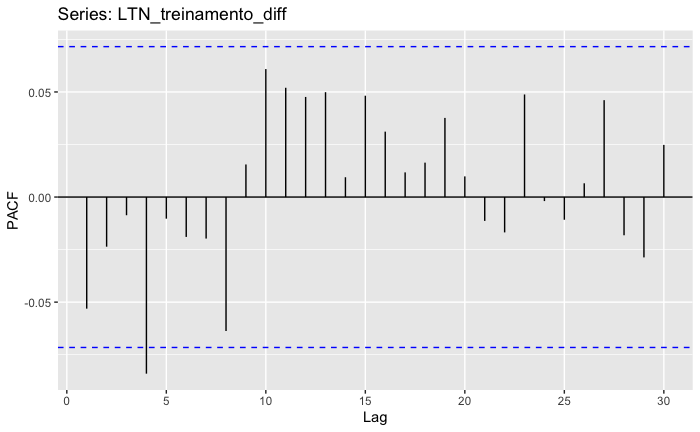

```r
ggPacf(LTN_treinamento_diff,30)
```

Conforme os gráficos ACF e PACF, apenas o lag de ordem 4 apresenta correlação significativa, indicando que o modelo pode ser um AR(4). Contudo, o gráfico ACF não possui um decaimento exponencial que é comum dos modelos AR. Abaixo testaremos essa hipótese de modelagem com AR(4).

```r
LTN_ar <- Arima(LTN_treinamento_diff, order = c(4,0,0))
LTN_ar <- Arima(LTN_treinamento_diff, order = c(4,0,0))
cat('Resultados do modelo AR(4) para a série diferenciada de preços da LTN:\n')
```

```
Resultados do modelo AR(4) para a série diferenciada de preços da LTN:
```

```r
LTN_ar
```

```
Series: LTN_treinamento_diff
ARIMA(4,0,0) with non-zero mean

Coefficients:
          ar1      ar2      ar3      ar4    mean
      -0.0554  -0.0258  -0.0126  -0.0852  0.4228
s.e.   0.0364   0.0364   0.0367   0.0367  0.1091

sigma^2 estimated as 12.48:  log likelihood=-2008.24
AIC=4028.48   AICc=4028.59   BIC=4056.2
```

```r
cat('\nEstatística dos coeficientes, isto é, a divisão do coeficiente pela variância:\n')
```

```
Estatística dos coeficientes, isto é, a divisão do coeficiente pela variância:
```

```r
LTN_ar_estat <- LTN_ar$coef/diag(LTN_ar$var.coef)
LTN_ar_estat
```

```
       ar1        ar2        ar3        ar4  intercept
-41.824584 -19.427290  -9.326452 -63.415443  35.512021
```

Agora podemos plotar o gráfico do modelo ajustado AR(4) e o gráfico da previsão para os dados de teste.

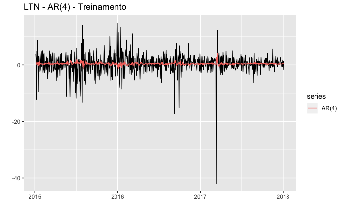

```r
LTN_ar_forecast <- forecast::forecast(LTN_ar, h=256)

autoplot(LTN_treinamento_diff) + autolayer(LTN_ar$fitted, series = 'AR(4)') +
  ggtitle("LTN - AR(4) - Treinamento")+ xlab("") + ylab("")
```

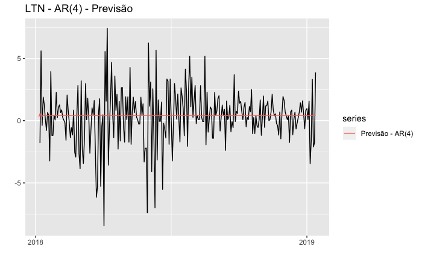

```r
autoplot(LTN_teste_diff) + autolayer(LTN_ar_forecast$mean, series = 'Previsão - AR(4)') +
    ggtitle("LTN - AR(4) - Previsão")+ xlab("") + ylab("")
```

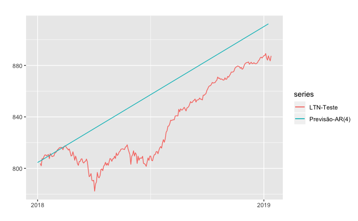

```r
# realizando a previsão na série de preços sem a diferenciação
LTN_ar_forecast_mean <- ts(cumsum(LTN_ar_forecast$mean) + LTN_treinamento[751], start =c(2018,1), frequency = 250)
autoplot(LTN_teste, series = 'LTN-Teste') + autolayer(LTN_ar_forecast_mean, series = 'Previsão-AR(4)') + xlab('') + ylab('')
```

Os gráficos demonstram um fraco ajuste do modelo AR(4) aos dados de treinamento e de teste. A seguir, calcularemos o MSE para o modelo AR(4).

```r
mse_LTN_ar <- MSE(LTN_teste, LTN_ar_forecast_mean)
mse_df[,1] <- as.character(mse_df[,1])
mse_df[2,1] <- 'AR(4)'
mse_df[2,2] <- mse_LTN_ar
mse_df
```

[output not shown]

```r
mse_add <- function(df, model, value, i){
  df[i,1] <- model
  df[i,2] <- value
  return(df)
}

cat('\nErro quadrático médio (MSE) do modelo AR(4) nos dados de Teste:',mse_LTN_ar)
```

```
Erro quadrático médio (MSE) do modelo AR(4) nos dados de Teste: 834.191
```

```r
cat('\nCritério informacional de Akaike (AIC):', LTN_ar$aicc)
```

```
Critério informacional de Akaike (AIC): 4028.589
```

```r
cat('\n')
```

O erro quadrático médio do modelo AR(4) foi 834.191, ao passo que o AIC foi 4028.589. Comparando o MSE do AR(4) com o modelo estimado pelo Holt-Winters (mse = s1181.7044857), percebe que o autorregressivo apresenta o menor valor, resultando em um modelo com melhor capacidade de previsão. Abaixo, apresentamos os resíduos do model estimado pelo AR(4).

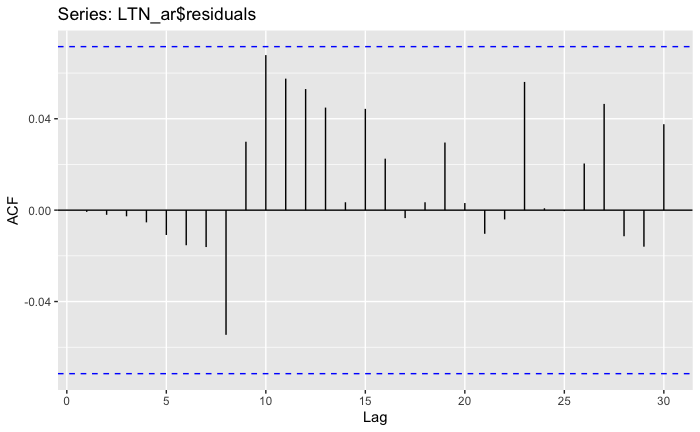

```r
ggAcf(LTN_ar$residuals, 30)
```

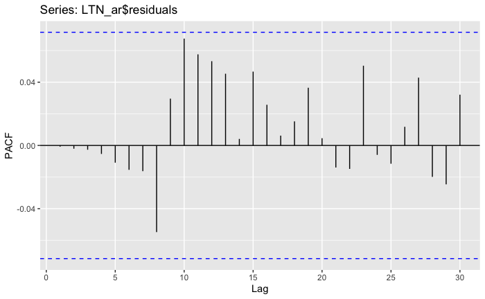

```r
ggPacf(LTN_ar$residuals, 30)
```

```r
LTN_ar_residuals <- LTN_ar$residuals
```

Os gráficos ACF e PACF dos resíduos do modelo AR(4) não apresentam autocorrelação e autocorrelação parcial significativas , garantindo que a série conseguiu ser modelada. A seguir, faremos a modelagem da série por meio do modelo ARMA.

#### ARMA

O modelo ARMA é uma extensão do AR uma vez que incorpora as Médias Móveis dos Erros. Esse modelo necessita que as séries sejam estacionárias e dessa maneira, utilizaremos os dados de treinamento e teste diferenciados.

Analisaremos novamente o ACF e PACF da série diferenciada para tentar supor uma hipótese de modelo ARMA(p,q).

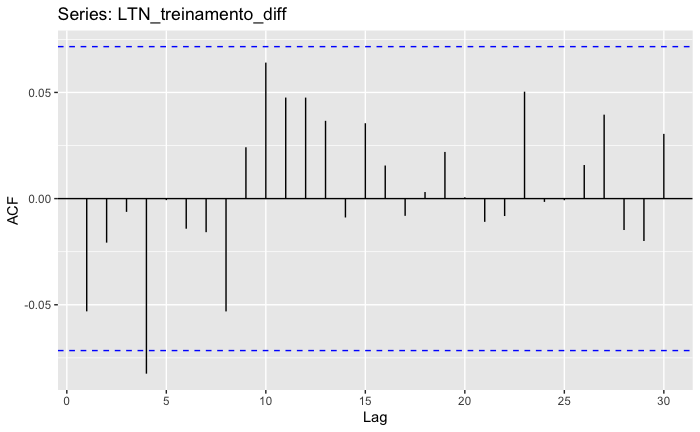

```r
ggAcf(LTN_treinamento_diff, 30)
```

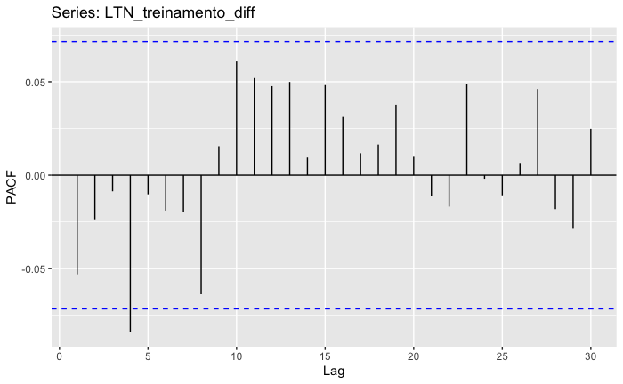

```r
ggPacf(LTN_treinamento_diff, 30)
```

Dos gráficos ACF e PACF, o modelo escolhido foi o ARMA(4,4), uma vez que o único Lag com significância estatística foi o de valor 4.

```r
LTN_arma <- Arima(LTN_treinamento_diff, order = c(4,0,4))
cat('Resultados do modelo ARMA(4,4) para a série diferenciada de preços da LTN:\n')
```

```
Resultados do modelo ARMA(4,4) para a série diferenciada de preços da LTN:
```

```r
LTN_arma
```

```
Series: LTN_treinamento_diff
ARIMA(4,0,4) with non-zero mean

Coefficients:
          ar1      ar2      ar3     ar4     ma1     ma2     ma3      ma4    mean
      -0.2876  -0.3251  -0.3642  0.6098  0.2381  0.2778  0.3343  -0.7054  0.4228
s.e.   0.1440   0.1348   0.1345  0.1393  0.1318  0.1259  0.1250   0.1323  0.1067

sigma^2 estimated as 12.3:  log likelihood=-2003.59
AIC=4027.17   AICc=4027.47   BIC=4073.37
```

```r
cat('\nEstatística dos coeficientes, isto é, a divisão do coeficiente pela variância:\n')
```

```
Estatística dos coeficientes, isto é, a divisão do coeficiente pela variância:
```

```r
LTN_arma_estat <- LTN_arma$coef/diag(LTN_arma$var.coef)
LTN_arma_estat
```

```
      ar1       ar2       ar3       ar4       ma1       ma2       ma3       ma4 intercept
-13.85824 -17.87711 -20.14465  31.43829  13.70956  17.52928  21.38954 -40.29189  37.15574
```

Verifica-se que todos os coeficientes são estatísticamente significativos à 5%, uma vez que as estatísticas são maiores do que 1.645 que é o valor crítico por uma Normal padrão.

Agora podemos plotar o gráfico do modelo ajustado ARMA(4,4) e o gráfico da previsão para os dados de teste.

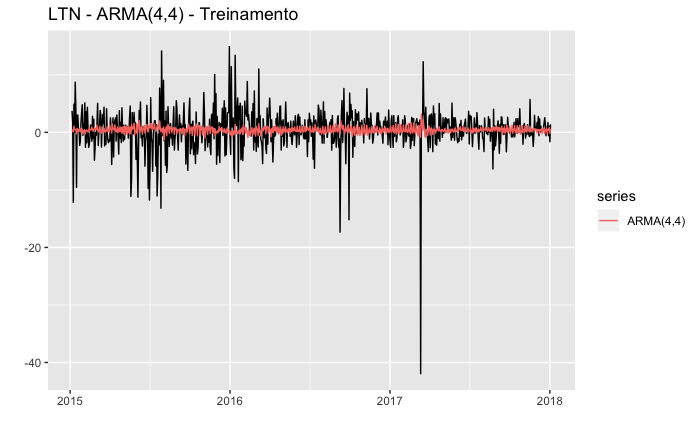

```r
LTN_arma_forecast <- forecast::forecast(LTN_arma, 256)

autoplot(LTN_treinamento_diff) + autolayer(LTN_arma$fitted,series = 'ARMA(4,4)') +
  ggtitle("LTN - ARMA(4,4) - Treinamento")+ xlab("") + ylab("")
```

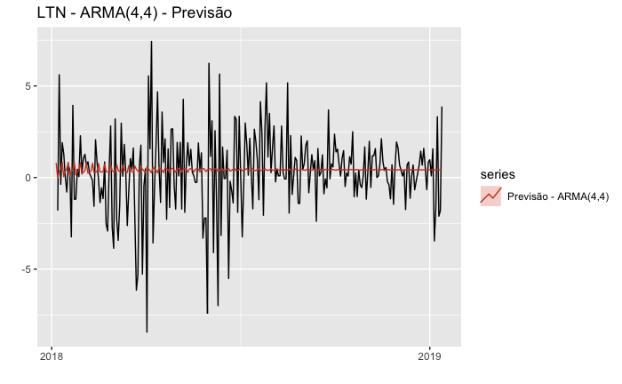

```r
autoplot(LTN_teste_diff) + autolayer(LTN_arma_forecast, PI=FALSE, series = 'Previsão - ARMA(4,4)') +
    ggtitle("LTN - ARMA(4,4) - Previsão")+ xlab("") + ylab("")
```

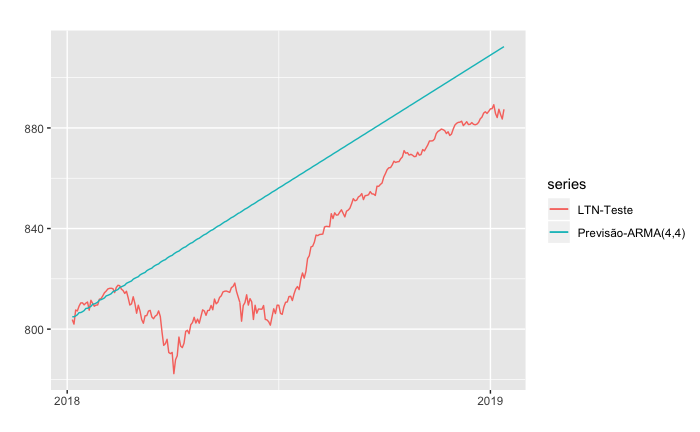

```r
# realizando a previsão na série de preços sem a diferenciação
LTN_arma_forecast_mean <- ts(cumsum(LTN_arma_forecast$mean) + LTN_treinamento[751], start =c(2018,4), frequency = 250)
autoplot(LTN_teste, series = 'LTN-Teste') + autolayer(LTN_arma_forecast_mean, series = 'Previsão-ARMA(4,4)') + xlab('') + ylab('')
```

Os gráficos demonstram um fraco ajuste do modelo ARMA(4,4) aos dados de treinamento e de teste. A seguir, calcularemos o MSE para o modelo ARMA(4,4).

```r
mse_LTN_arma <- MSE(LTN_teste, LTN_arma_forecast_mean)
mse_df <- mse_add(mse_df, model = 'ARMA(4,4)', value = mse_LTN_arma, i = 3)
mse_df
```

[output not shown]

```r
cat('\nErro quadrático médio (MSE) do modelo ARMA(4,4) nos dados de Teste:',mse_LTN_arma)
```

```
Erro quadrático médio (MSE) do modelo ARMA(4,4) nos dados de Teste: 772.0561
```

```r
cat('\nCritério informacional de Akaike (AIC):', LTN_arma$aicc)
```

```
Critério informacional de Akaike (AIC): 4027.471
```

O modelo ARMA(4,4) apresentou um MSE menor do que o AR(4) para os dados de teste. Esse resultado indica que o modelo ARMA(4,4) possui melhor capacidade preditiva.

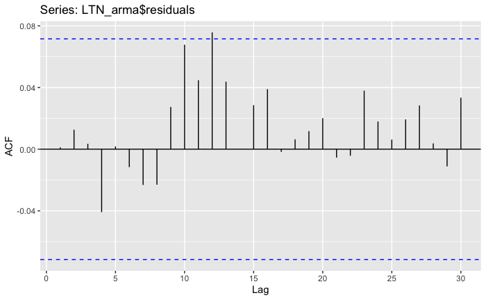

```r
ggAcf(LTN_arma$residuals,30)
```

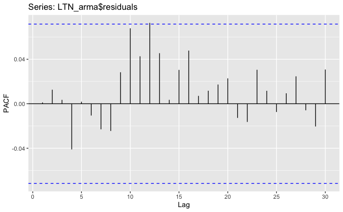

```r
ggPacf(LTN_arma$residuals,30)
```

#### ARIMA

O modelo ARIMA se diferencia do ARMA, pois possui um operador de diferenciação implementado em sua estimação. Dessa maneira, não é necessário utilizar uma série diferenciada para estimar pelo ARIMA. Basta que defina a ordem de diferenciação no procedimento de estimação. Dessa feita, estimaremos o modelo ARIMA(4,1,4) e ARIMA(4,1,0) com o intuito de avaliar qual desses modelos apresenta menor erro de previsão.

```
Resultados do modelo ARIMA(4,1,0) para a série diferenciada de preços da LTN:
Series: LTN_treinamento
ARIMA(4,1,0)

Coefficients:
          ar1      ar2     ar3      ar4
      -0.0384  -0.0082  0.0059  -0.0678
s.e.   0.0364   0.0365  0.0367   0.0367

sigma^2 estimated as 12.7:  log likelihood=-2015.23
AIC=4040.46   AICc=4040.54   BIC=4063.56

Estatística dos coeficientes, isto é, a divisão do coeficiente pela variância:
       ar1        ar2        ar3        ar4
-28.912891  -6.151180   4.349145 -50.321102
```

```
Resultados do modelo ARIMA(4,1,4) para a série diferenciada de preços da LTN:
Series: LTN_treinamento
ARIMA(4,1,4)

Coefficients:
```

```
NaNs produced
```

```
          ar1     ar2      ar3      ar4     ma1     ma2     ma3     ma4
      -0.5471  -0.519  -1.0000  -0.2479  0.5083  0.5050  1.0041  0.1847
s.e.   0.3816     NaN   0.1504   0.3220  0.3907  0.0557  0.1587  0.3418

sigma^2 estimated as 12.64:  log likelihood=-2013.47
AIC=4044.95   AICc=4045.19   BIC=4086.53

Estatística dos coeficientes, isto é, a divisão do coeficiente pela variância:
       ar1        ar2        ar3        ar4        ma1        ma2        ma3        ma4
 -3.758206 508.205114 -44.227451  -2.391831   3.330247 163.028171  39.873278   1.581565
```

Estimados os modelos arima, apresentamos as previsões pontuais e plotamos os gráficos.

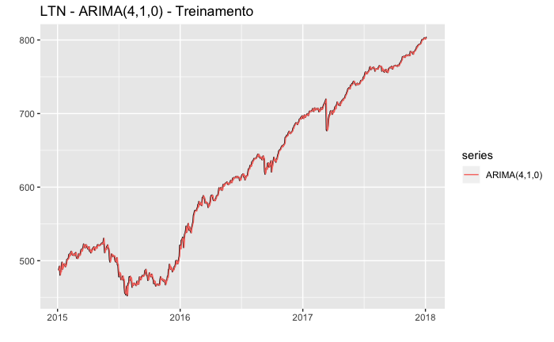

```r
LTN_arima_1_forecast <- forecast::forecast(LTN_arima_1, 256)
LTN_arima_2_forecast <- forecast::forecast(LTN_arima_2, 256)

autoplot(LTN_treinamento) + autolayer(LTN_arima_1$fitted, series = 'ARIMA(4,1,0)')  +
  ggtitle("LTN - ARIMA(4,1,0) - Treinamento")+ xlab("") + ylab("")
```

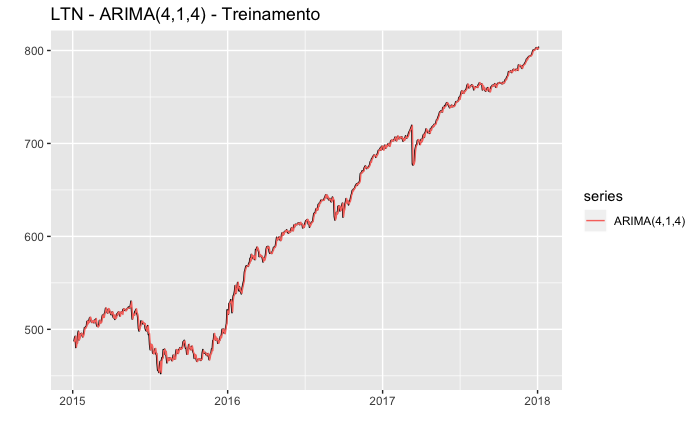

```r
autoplot(LTN_treinamento)  +
  autolayer(LTN_arima_2$fitted, series = 'ARIMA(4,1,4)') +
  ggtitle("LTN - ARIMA(4,1,4) - Treinamento")+ xlab("") + ylab("")
```

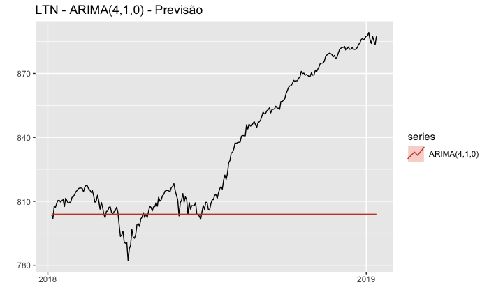

```r
autoplot(LTN_teste) + autolayer(LTN_arima_1_forecast,PI = FALSE, series = 'ARIMA(4,1,0)')  +
    ggtitle("LTN - ARIMA(4,1,0) - Previsão")+ xlab("") + ylab("")
```

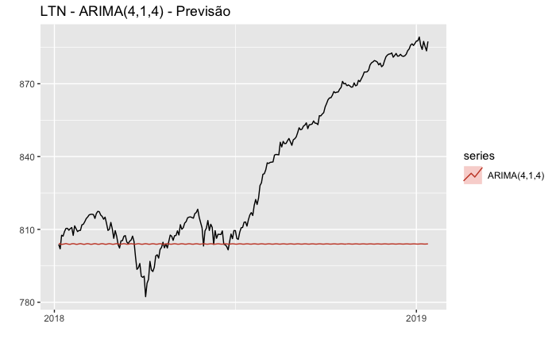

```r
autoplot(LTN_teste)  +
  autolayer(LTN_arima_2_forecast,PI=FALSE, series = 'ARIMA(4,1,4)') +
    ggtitle("LTN - ARIMA(4,1,4) - Previsão")+ xlab("") + ylab("")
```

```r
mse_LTN_arima_1 <- MSE(LTN_teste, LTN_arima_1_forecast$mean)
cat('\nErro quadrático médio (MSE) do modelo ARIMA(4,1,0) nos dados de Teste:',mse_LTN_arima_1)
```

```
Erro quadrático médio (MSE) do modelo ARIMA(4,1,0) nos dados de Teste: 1861.968
```

```r
cat('\nCritério informacional de Akaike (AIC):', LTN_arima_1$aicc)
```

```
Critério informacional de Akaike (AIC): 4040.544
```

```r
mse_df <- mse_add(mse_df, model = 'ARIMA(4,1,0)', value = mse_LTN_arima_1, i = 4)

mse_LTN_arima_2 <- MSE(LTN_teste, LTN_arima_2_forecast$mean)
cat('\nErro quadrático médio (MSE) do modelo ARIMA(4,1,4) nos dados de Teste:',mse_LTN_arima_2)
```

```
Erro quadrático médio (MSE) do modelo ARIMA(4,1,4) nos dados de Teste: 1860.695
```

```r
cat('\nCritério informacional de Akaike (AIC):', LTN_arima_2$aicc)
```

```
Critério informacional de Akaike (AIC): 4045.192
```

```r
cat('\n')
```

```r
mse_df <- mse_add(mse_df, model = 'ARIMA(4,1,4)', value = mse_LTN_arima_1, i = 5)
mse_df
```

[output not shown]

Vamos analisar os resíduos da série produzida pelo ARIMA(4,1,0) e ARIMA(4,1,4).

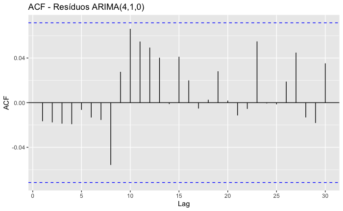

```r
ggAcf(LTN_arima_1$residuals,30) + ggtitle('ACF - Resíduos ARIMA(4,1,0)')
```

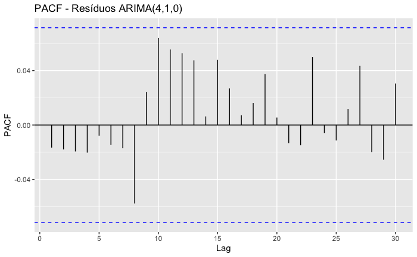

```r
ggPacf(LTN_arima_1$residuals,30) + ggtitle('PACF - Resíduos ARIMA(4,1,0)')
```

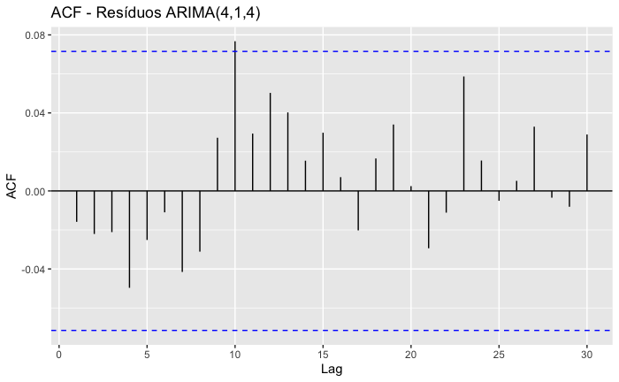

```r
ggAcf(LTN_arima_2$residuals,30) + ggtitle('ACF - Resíduos ARIMA(4,1,4)')
```

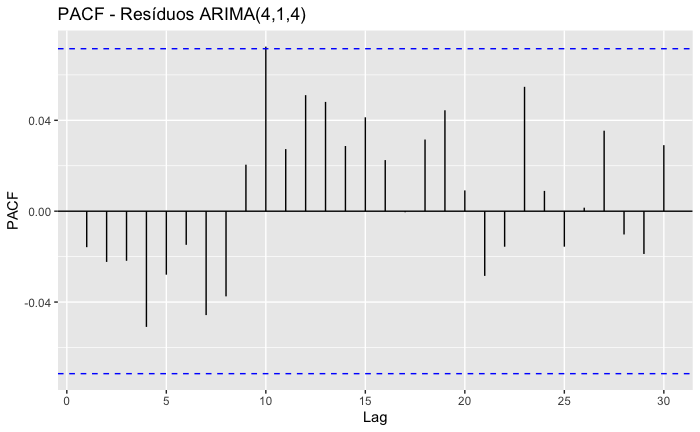

```r
ggPacf(LTN_arima_2$residuals,30) + ggtitle('PACF - Resíduos ARIMA(4,1,4)')
```

#### GARCH

Os modelos da família ARCH (autorregressivo de heterocedasticiadade condicional) servem para realizar previsão de volatilidade. É imprescindível a sua utilização nas finanças, uma vez que as séries de retorno são não-autocorrelacionadas, mas que possuem a variância condicional ao tempo.

Desse modo, realizamos o cálculo da variância da série diferenciada, como se pode verificar abaixo.

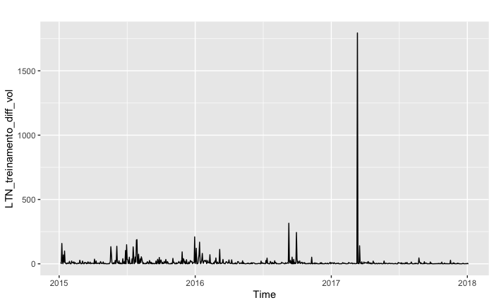

```r
# criação da série de volatilidade
LTN_treinamento_diff_vol <- (LTN_treinamento_diff - mean(LTN_treinamento_diff))^2
LTN_teste_diff_vol <- (LTN_teste_diff - mean(LTN_teste_diff))^2
# plotando a série de volatilidade
autoplot(LTN_treinamento_diff_vol)
```

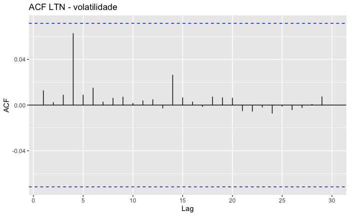

```r
# ACF e PACF da volatilidade
ggAcf(LTN_treinamento_diff_vol, 30) + ggtitle('ACF LTN - volatilidade')
```

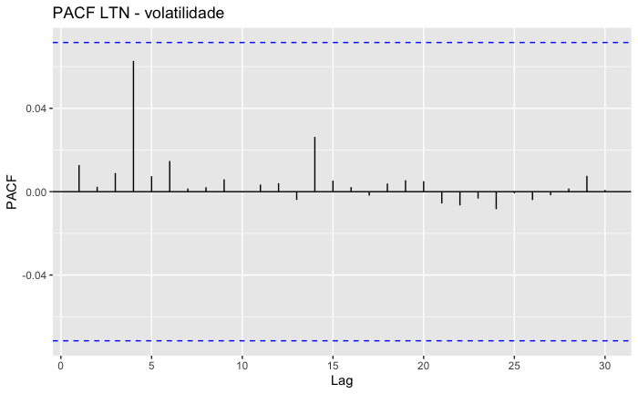

```r
ggPacf(LTN_treinamento_diff_vol, 30) + ggtitle('PACF LTN - volatilidade')
```

A série de volatilidade da diferença dos Preços da LTN não apresenta autocorrelação, contudo escolhemos o modelo GARCH(1,1) para investigar sua capacidade de previsão. Segue o modelo com o gráfico dos dados de treinamento e de teste.

```r
# Garch(1,1)
LTN_garch <- garch(LTN_treinamento_diff,order=c(1,1))
```

[output not shown]

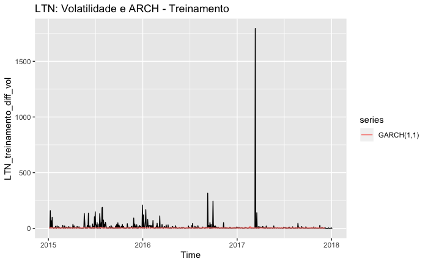

```r
# Plotando dados de treinamento e modelo GARCH(1,1)
autoplot(LTN_treinamento_diff_vol)+autolayer(ts(LTN_garch$fitted.values[-1,1],start=c(2015,3),frequency=256), series = 'GARCH(1,1)') + ggtitle('LTN: Volatilidade e ARCH - Treinamento')
```

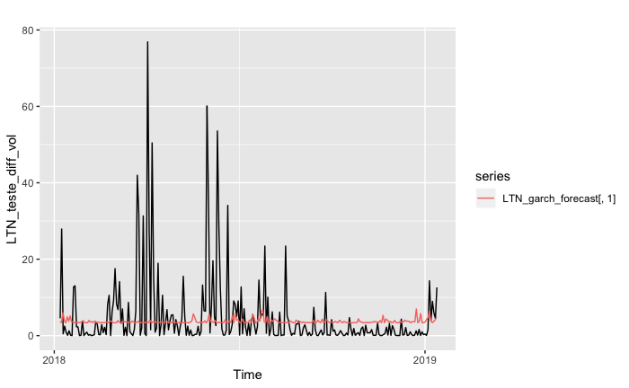

```r
# Prevendo com o modelo GARCH(1,1)
LTN_garch_forecast <- ts(predict(LTN_garch, n.ahead = 256),start=c(2018,4),end=c(2019,9),frequency=256)
#Plotando o gráfico da previsão com os dados de teste
autoplot(LTN_teste_diff_vol) + autolayer(LTN_garch_forecast[,1])
```

A seguir, apresentamos os valor do MSE para o GARCH(1,1)

```r
mse_LTN_garch <- MSE(LTN_teste_diff_vol[-1], LTN_garch_forecast[-1,1])
```

```
longer object length is not a multiple of shorter object length
```

```r
cat('\nErro quadrático médio (MSE) do modelo GARCH(1,1) nos dados de Teste da volatilidade:',mse_LTN_garch)
```

```
Erro quadrático médio (MSE) do modelo GARCH(1,1) nos dados de Teste da volatilidade: 97.13782
```

```r
cat('\n')
```

```r
mse_df <- mse_add(mse_df, model = 'GARCH(1,1)', value = mse_LTN_garch, i = 6)
mse_df
```

[output not shown]

```r
NA
```

Vale ressaltar que o resultado do MSE do GARCH(1,1) não serve de comparação com os demais modelos, pois aquele serve para modelar a Volatilidade, sendo diferente dos demais.